# Exploring the BRFSS data

## Setup

### Load packages

```r
library(ggplot2)
library(dplyr)
library(ggmosaic)
library(RColorBrewer)

theme_set(theme_classic())
```

### Load data

```r
load("brfss2013.RData")
```

## Part 1: Data

The background context regarding the assignment can be found at: https://www.coursera.org/learn/probability-intro/supplement/1E7zQ/project-information.

### Behavioral Risk Factor Surveillance System

The Behavioral Risk Factor Surveillance System (BRFSS) is a collaborative project between all of the states in the United States (US) and participating US territories and the Centers for Disease Control and Prevention (CDC). The BRFSS is administered and supported by CDC’s Population Health Surveillance Branch, under the Division of Population Health at the National Center for Chronic Disease Prevention and Health Promotion. BRFSS is an ongoing surveillance system designed to measure behavioral risk factors for the non-institutionalized adult population (18 years of age and older) residing in the US. The BRFSS objective is to collect uniform, state-specific data on preventive health practices and risk behaviors that are linked to chronic diseases, injuries, and preventable infectious diseases that affect the adult population.

Factors assessed by the BRFSS in 2013 include tobacco use, HIV/AIDS knowledge and prevention, exercise, immunization, health status, healthy days — health-related quality of life, health care access, inadequate sleep, hypertension awareness, cholesterol awareness, chronic health conditions, alcohol consumption, fruits and vegetables consumption, arthritis burden, and seatbelt use.

Further details about the BRFSS can be obtained from this link: https://www.cdc.gov/brfss/annual_data/2013/pdf/Overview_2013.pdf

### Data collection

BRFSS conducts both landline telephone- and cellular telephone-based surveys. In conducting the BRFSS landline telephone survey, interviewers collect data from a randomly selected adult in a household. In conducting the cellular telephone version of the BRFSS questionnaire, interviewers collect data from an adult who participates by using a cellular telephone and resides in a private residence or college housing.

## Part 2: Research questions

**Research question 1:** Is there any correlation between individual income levels and their impact on healthcare coverage and checkup frequency?

**Research question 2:** Is there any relationship between the number of sleep hours and the general health of the population as reported by the individuals surveyed?

**Research question 3:** Is there any relationship between education level and general health and healthcare coverage?

## Part 3: Exploratory data analysis

**Data cleaning**

```r
rq <-
  brfss2013 %>%
  select(income2, hlthpln1, checkup1, genhlth, sleptim1, educa)

summary(rq)
```

```
##               income2       hlthpln1                     checkup1
##  $75,000 or more  :115902   Yes :434571   Within past year   :356228
##  Less than $75,000: 65231   No  : 55300   Within past 2 years: 57298
##  Less than $50,000: 61509   NA's:  1904   Within past 5 years: 33674
##  Less than $35,000: 48867                 5 or more years ago: 33748
##  Less than $25,000: 41732                 Never              :  4522
##  (Other)          : 87108                 NA's               :  6305
##  NA's             : 71426
##       genhlth          sleptim1
##  Excellent: 85482   Min.   :  0.000
##  Very good:159076   1st Qu.:  6.000
##  Good     :150555   Median :  7.000
##  Fair     : 66726   Mean   :  7.052
##  Poor     : 27951   3rd Qu.:  8.000
##  NA's     :  1985   Max.   :450.000
##                     NA's   :7387
##                                                           educa
##  Never attended school or only kindergarten                  :   677
##  Grades 1 through 8 (Elementary)                             : 13395
##  Grades 9 though 11 (Some high school)                       : 28141
##  Grade 12 or GED (High school graduate)                      :142971
##  College 1 year to 3 years (Some college or technical school):134197
##  College 4 years or more (College graduate)                  :170120
##  NA's                                                        :  2274
```

There appear to be some outliers in the `sleptim1` variables, making the distribution right-skewed. As the question related to the variable asked how many hours of sleep respondents get in 24 hours, we can safely remove the value above 24. We also need to remove any rows with NA.

```r
rq <-
  rq %>%
  filter(sleptim1 <= 24) %>%
  na.omit()

summary(rq)
```

```
##               income2       hlthpln1                    checkup1
##  $75,000 or more  :114381   Yes:363433   Within past year   :297725
##  Less than $75,000: 64191   No : 45907   Within past 2 years: 49337
##  Less than $50,000: 60211                Within past 5 years: 29347
##  Less than $35,000: 47466                5 or more years ago: 29282
##  Less than $25,000: 40386                Never              :  3649
##  Less than $20,000: 33449
##  (Other)          : 49256
##       genhlth          sleptim1
##  Excellent: 73070   Min.   : 1.000
##  Very good:136151   1st Qu.: 6.000
##  Good     :124667   Median : 7.000
##  Fair     : 53706   Mean   : 7.033
##  Poor     : 21746   3rd Qu.: 8.000
##                     Max.   :24.000
##
##                                                           educa
##  Never attended school or only kindergarten                  :   417
##  Grades 1 through 8 (Elementary)                             :  9559
##  Grades 9 though 11 (Some high school)                       : 21340
##  Grade 12 or GED (High school graduate)                      :115059
##  College 1 year to 3 years (Some college or technical school):113348
##  College 4 years or more (College graduate)                  :149617
##
```

**Distribution of related variables**

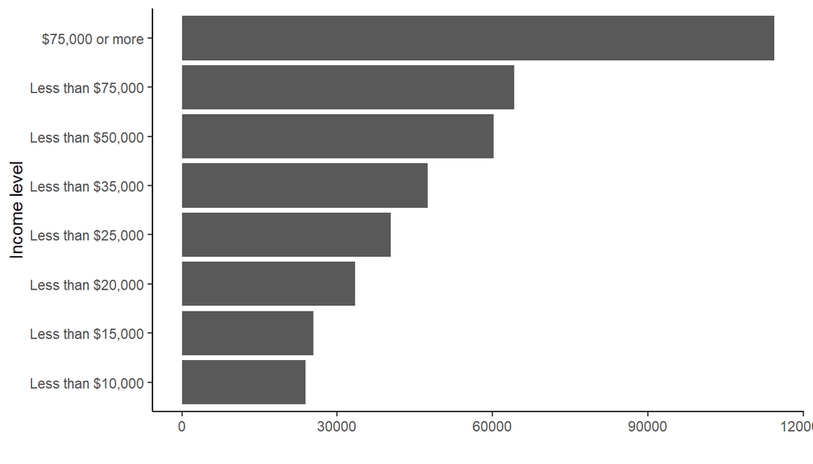

```r
rq %>%
  ggplot(aes(income2)) +
  geom_bar() +
  coord_flip() +
  labs(
    x = "Income level",
    y = ""
  )
```

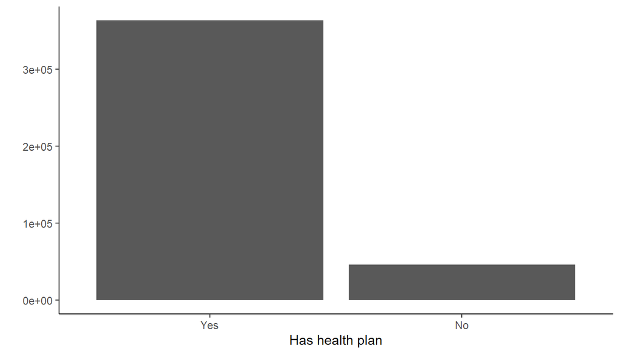

```r
rq %>%
  ggplot(aes(hlthpln1)) +
  geom_bar() +
  labs(
    x = "Has health plan",
    y = ""
  )
```

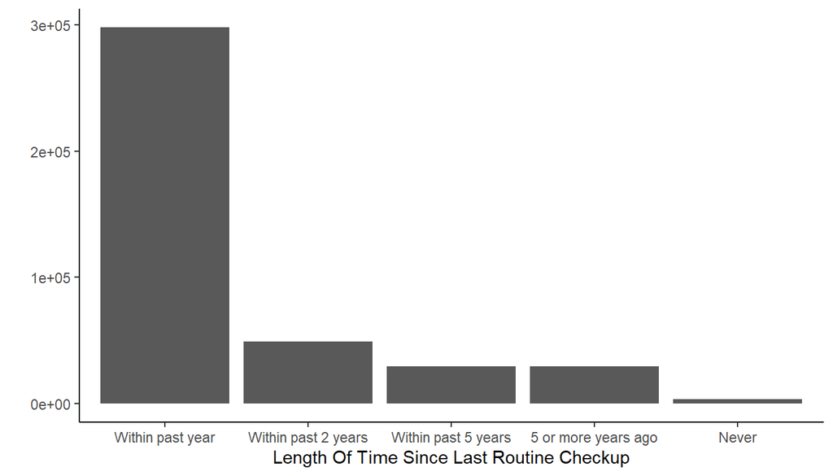

```r
rq %>%
  ggplot(aes(checkup1)) +
  geom_bar() +
  labs(
    x = "Length Of Time Since Last Routine Checkup",
    y = ""
  )
```

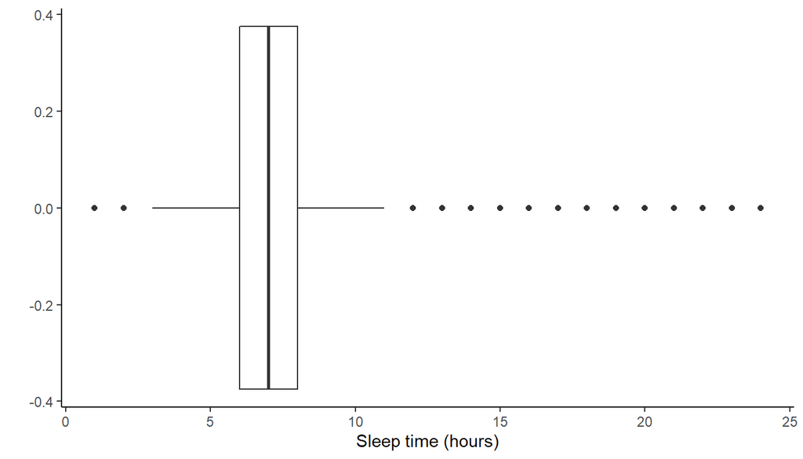

```r
rq %>%
  ggplot(aes(sleptim1)) +
  geom_boxplot() +
  labs(
    x = "Sleep time (hours)",
    y = ""
  )
```

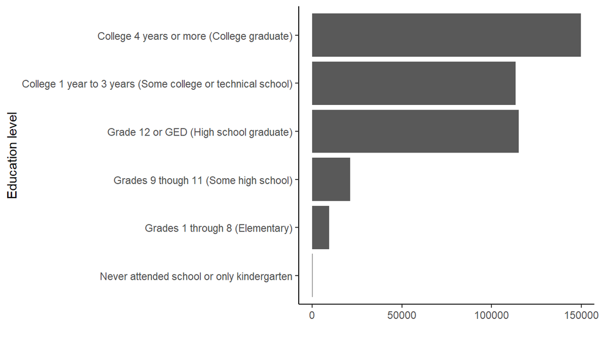

```r
rq %>%
  ggplot(aes(educa)) +
  geom_bar() +
  coord_flip() +
  labs(
    x = "Education level",
    y = ""
  )
```

**Research question 1:**

```r
rq1 <-
  rq %>%
  select(income2, hlthpln1, checkup1, genhlth)

summary(rq1)
```

```
##               income2       hlthpln1                    checkup1
##  $75,000 or more  :114381   Yes:363433   Within past year   :297725
##  Less than $75,000: 64191   No : 45907   Within past 2 years: 49337
##  Less than $50,000: 60211                Within past 5 years: 29347
##  Less than $35,000: 47466                5 or more years ago: 29282
##  Less than $25,000: 40386                Never              :  3649
##  Less than $20,000: 33449
##  (Other)          : 49256
##       genhlth
##  Excellent: 73070
##  Very good:136151
##  Good     :124667
##  Fair     : 53706
##  Poor     : 21746
##
##
```

```r
income_hlth <-
  rq1 %>%
  group_by(income2) %>%
  count(hlthpln1) %>%
  print()
```

```
## # A tibble: 16 × 3
## # Groups:   income2 [8]
##    income2           hlthpln1      n
##    <fct>             <fct>     <int>
##  1 Less than $10,000 Yes       17622
##  2 Less than $10,000 No         6208
##  3 Less than $15,000 Yes       20074
##  4 Less than $15,000 No         5352
##  5 Less than $20,000 Yes       25683
##  6 Less than $20,000 No         7766
##  7 Less than $25,000 Yes       32335
##  8 Less than $25,000 No         8051
##  9 Less than $35,000 Yes       40667
## 10 Less than $35,000 No         6799
## 11 Less than $50,000 Yes       54524
## 12 Less than $50,000 No         5687
## 13 Less than $75,000 Yes       60846
## 14 Less than $75,000 No         3345
## 15 $75,000 or more   Yes      111682
## 16 $75,000 or more   No         2699
```

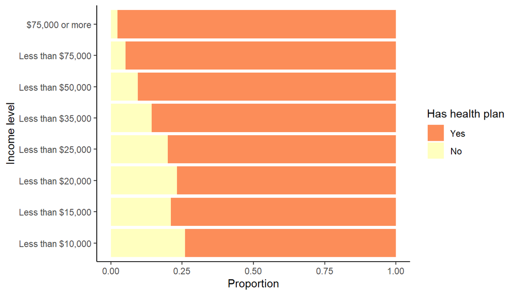

```r
income_hlth %>%
  ggplot(aes(income2, n, fill = hlthpln1)) +
  geom_bar(position = "fill", stat = "identity") +
  coord_flip() +
  labs(
    x = "Income level",
    y = "Proportion",
    fill = "Has health plan"
  ) +
  scale_fill_brewer(palette = "Spectral")
```

From the above figure, the proportion of respondents with a healthcare plan increase as the income level increase.

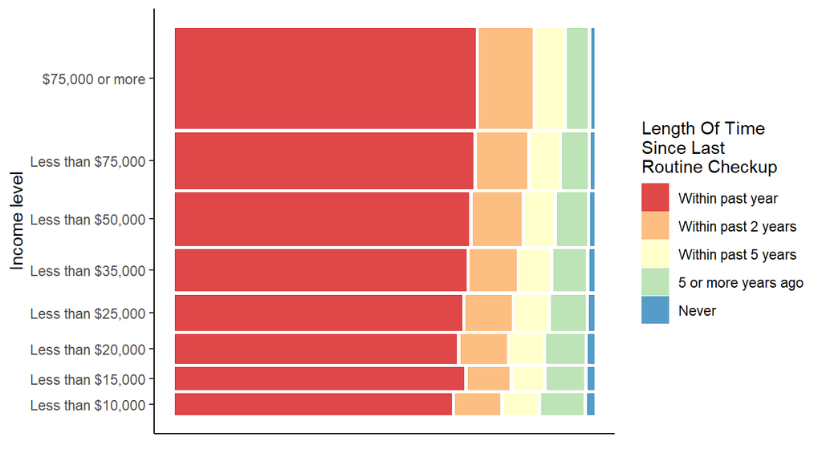

```r
rq1 %>%
  ggplot() +
  geom_mosaic(aes(product(income2), fill = checkup1)) +
  coord_flip() +
  labs(
    x = "Income level",
    y = "",
    fill = "Length Of Time\nSince Last\nRoutine Checkup"
  ) +
  theme(
    axis.text.x = element_blank(),
    axis.ticks.x = element_blank()
  ) +
  scale_fill_brewer(palette = "Spectral")
```

There appears to be no correlation between income level and length of time since the last routine checkup as the majority of the respondents with different income levels had routine checkups within the past year.

**Research question 2:**

```r
rq2 <-
  rq %>%
  select(sleptim1, genhlth)

summary(rq2)
```

```
##     sleptim1           genhlth
##  Min.   : 1.000   Excellent: 73070
##  1st Qu.: 6.000   Very good:136151
##  Median : 7.000   Good     :124667
##  Mean   : 7.033   Fair     : 53706
##  3rd Qu.: 8.000   Poor     : 21746
##  Max.   :24.000
```

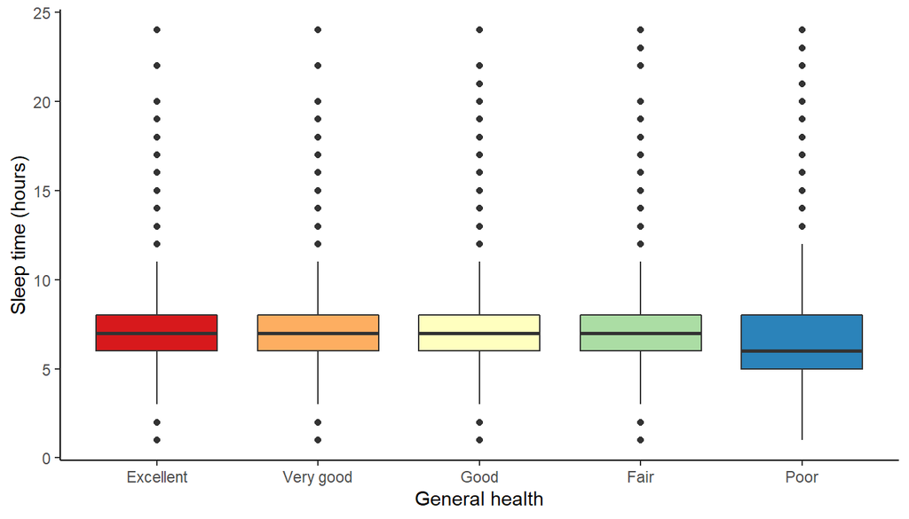

```r
rq2 %>%
  ggplot(aes(genhlth, sleptim1, fill = genhlth)) +
  geom_boxplot() +
  labs(
    x = "General health",
    y = "Sleep time (hours)"
  ) +
  theme(
    legend.position = "none"
  ) +
  scale_fill_brewer(palette = "Spectral")
```

**Research question 3:**

```r
rq3 <-
  rq %>%
  select(educa, hlthpln1, checkup1, genhlth)

summary(rq3)
```

```
##                                                           educa
##  Never attended school or only kindergarten                  :   417
##  Grades 1 through 8 (Elementary)                             :  9559
##  Grades 9 though 11 (Some high school)                       : 21340
##  Grade 12 or GED (High school graduate)                      :115059
##  College 1 year to 3 years (Some college or technical school):113348
##  College 4 years or more (College graduate)                  :149617
##  hlthpln1                    checkup1           genhlth
##  Yes:363433   Within past year   :297725   Excellent: 73070
##  No : 45907   Within past 2 years: 49337   Very good:136151
##               Within past 5 years: 29347   Good     :124667
##               5 or more years ago: 29282   Fair     : 53706
##               Never              :  3649   Poor     : 21746
##
```

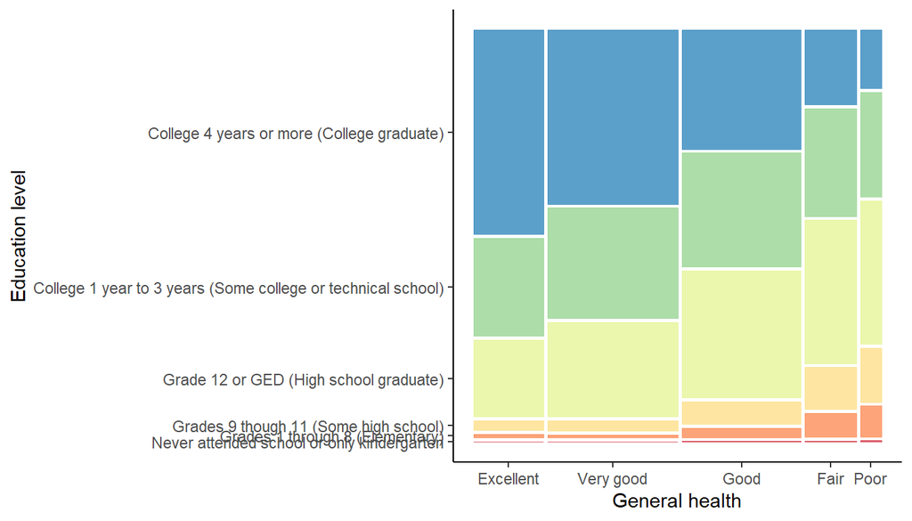

```r
rq3 %>%
  ggplot() +
  geom_mosaic(aes(product(genhlth), fill = educa)) +
  labs(
    x = "General health",
    y = "Education level"
  ) +
  theme(
    legend.position = "none",
    plot.title = element_text(hjust = 0.5)
  ) +
  scale_fill_brewer(palette = "Spectral")
```

From the mosaic plot above, we can see that respondent who has at least 4 years of college reported better general health. Likewise, there is a direct correlation between the number of years spent in education and the reported levels of general health amongst the individuals surveyed.

```r
edu_hlth <- rq3 %>%
  filter(!is.na(educa) & !is.na(hlthpln1)) %>%
  group_by(educa) %>%
  count(hlthpln1) %>%
  print()
```

```
## # A tibble: 12 × 3
## # Groups:   educa [6]
##    educa                                                        hlthpln1      n
##    <fct>                                                        <fct>     <int>
##  1 Never attended school or only kindergarten                   Yes         266
##  2 Never attended school or only kindergarten                   No          151
##  3 Grades 1 through 8 (Elementary)                              Yes        7039
##  4 Grades 1 through 8 (Elementary)                              No         2520
##  5 Grades 9 though 11 (Some high school)                        Yes       16278
##  6 Grades 9 though 11 (Some high school)                        No         5062
##  7 Grade 12 or GED (High school graduate)                       Yes       98149
##  8 Grade 12 or GED (High school graduate)                       No        16910
##  9 College 1 year to 3 years (Some college or technical school) Yes      100051
## 10 College 1 year to 3 years (Some college or technical school) No        13297
## 11 College 4 years or more (College graduate)                   Yes      141650
## 12 College 4 years or more (College graduate)                   No         7967
```

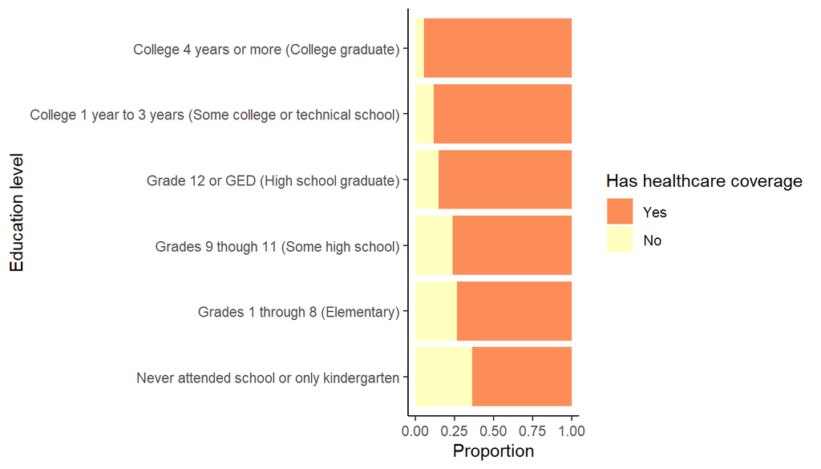

```r
edu_hlth %>%
  ggplot(aes(educa, n, fill = hlthpln1)) +
  geom_bar(position="fill", stat="identity") +
  coord_flip() +
  labs(
    x = "Education level",
    y = "Proportion",
    fill = "Has healthcare coverage"
  ) +
  scale_fill_brewer(palette = "Spectral")
```

Overall, the proportion of respondents with healthcare coverage is higher than those without. There is a clear relationship between education level and healthcare coverage as the higher the education level, the higher the proportion of respondents with healthcare coverage.